# assignment_1_regex

```python
import sys
import re
```

```python
print(sys.version)
```

```
3.11.9 | packaged by Anaconda, Inc. | (main, Apr 19 2024, 16:40:41) [MSC v.1916 64 bit (AMD64)]
```

```python
import string
from itertools import chain

import pandas as pd
import nltk
from nltk.corpus import wordnet, stopwords
from nltk.tokenize import(
    word_tokenize,
    wordpunct_tokenize,
    WhitespaceTokenizer,
    RegexpTokenizer,
    sent_tokenize
)
```

```python
import matplotlib.pyplot as plt
```

```python
from nltk.stem import PorterStemmer, LancasterStemmer, WordNetLemmatizer
```

```python
# Load the dataset
file_path = 'Food_Inspections_20241007.csv'  # Update with the actual file path
data = pd.read_csv(file_path)
```

```python
data.head(5)
```

|  | Inspection ID | DBA Name | AKA Name | License # | Facility Type | Risk | Address | City | State | Zip | Inspection Date | Inspection Type | Results | Violations | Latitude | Longitude | Location |
| --- | --- | --- | --- | --- | --- | --- | --- | --- | --- | --- | --- | --- | --- | --- | --- | --- | --- |
| 0 | 2604125 | ALPHA LEARNING CENTER | ALPHA LEARNING CENTER | 2354949.0 | Daycare Above and Under 2 Years | Risk 1 (High) | 8422 S DAMEN AVE | CHICAGO | IL | 60620.0 | 10/04/2024 | Canvass | Pass | 55. PHYSICAL FACILITIES INSTALLED, MAINTAINED ... | 41.740408 | -87.673048 | (41.74040790067068, -87.67304765547495) |
| 1 | 2604065 | CHINA PALACE | CHINA PALACE | 2476335.0 | Restaurant | Risk 1 (High) | 1129 W THORNDALE AVE | CHICAGO | IL | 60660.0 | 10/03/2024 | Complaint | Fail | 10. ADEQUATE HANDWASHING SINKS PROPERLY SUPPLI... | 41.989925 | -87.659440 | (41.98992502738334, -87.65943957792769) |
| 2 | 2604009 | SIGNATURE BAR | SIGNATURE BAR | 2989105.0 | Restaurant | Risk 3 (Low) | 1312 S WABASH AVE | CHICAGO | IL | 60605.0 | 10/03/2024 | License | Pass | NaN | 41.865345 | -87.625933 | (41.86534538408344, -87.62593260235937) |
| 3 | 2603951 | 303 MARKET | 303 MARKET | 2988181.0 | Grocery Store | Risk 3 (Low) | 303 E WACKER DR | CHICAGO | IL | 60601.0 | 10/02/2024 | License | Pass | NaN | 41.887705 | -87.620588 | (41.88770537937826, -87.62058814392799) |
| 4 | 2603937 | TOTS N TALES PRE-SCHOOL II | TOTS N TALES PRE-SCHOOL II | 2215492.0 | Daycare Above and Under 2 Years | Risk 1 (High) | 5784 S ARCHER AVE | CHICAGO | IL | 60638.0 | 10/02/2024 | Canvass | Out of Business | NaN | 41.796530 | -87.757837 | (41.79652962537552, -87.75783710916086) |

```python
data.iloc[0].Violations
```

```
'55. PHYSICAL FACILITIES INSTALLED, MAINTAINED & CLEAN - Comments: MUST REPAIR OR REPLACE STAINED CEILING TILES IN KIDS TOILET ROOM.'
```

```python
data.iloc[1].Violations
```

```
'10. ADEQUATE HANDWASHING SINKS PROPERLY SUPPLIED AND ACCESSIBLE - Comments: NOTED NO PAPER TOWELS LOCATED AT THE KITCHEN HAND WASHING SINK. MUST PROVIDE PAPER TOWELS AT ALL TIMES AT ALL HAND WASHING SINKS FOR PROPER HAND WASHING. PRIORITY FOUNDATION VIOLATION 7-38-030 CITATION ISSUED. | 23. PROPER …
```

### 1. Select only the records corresponding to failed inspections (see the "results" column).

```python
# Filter the data for failed inspections
failed_inspections = data[data['Results'] == 'Fail']
```

### 2. Use regular expressions to extract the regulation description and inspector comments from the "violations" columns.

```python
# Define a regex pattern to capture the regulation description and comments
pattern = r'\d+\.\s([A-Za-z\s,;&]+)\s-\sComments:\s(.+)'
```

[A-Za-z\s,;&]: This character class matches any uppercase or lowercase letter (A-Za-z), space (\s), comma (,), semicolon (;), or ampersand (&).

+: This means "one or more" of the above characters.

() (parentheses): These are used to create a capture group, which means the part matched by this regex will be stored for later use (for example, extract the regulation description using this group).

\s-\s it matches the - between the regulation description and the comments.

Comments:\s: This explicitly matches the "Comments:" followed by a space. By including this in the pattern but not in the capture group, it ensures that "Comments: " is recognized but not captured.

(.+): This remains the same to capture everything that comes after "Comments: " without including "Comments: " itself.

**For the text:**

55. PHYSICAL FACILITIES INSTALLED, MAINTAINED & CLEAN - Comments: MUST REPAIR OR REPLACE STAINED CEILING TILES IN KIDS TOILET ROOM.

\d+ matches 55.

. matches the period after 55.

\s matches the space after the period.

([A-Za-z\s,;&]+) **captures** the regulation description: PHYSICAL FACILITIES INSTALLED, MAINTAINED & CLEAN.

\s-\s matches the - separating the description from the comments.

(.+) **captures** the comments: MUST REPAIR OR REPLACE STAINED CEILING TILES IN KIDS TOILET ROOM.

It Captures:

Group 1: The regulation description.

Group 2: The comments.

`re.search()` finds the **first** instance of a match **anywhere** in the string and returns a `Match` object. If no pattern is found, a `None` is returned.

```python
# Extraction logic to handle both single and multiple violations
violations_data = []

for index, row in failed_inspections.iterrows():
    if pd.notna(row['Violations']):
        # If there's a '|' (multiple reasons), split and process each part
        if '|' in row['Violations']:
            violations = row['Violations'].split('|')
        else:
            # If no '|', treat it as a single violation
            violations = [row['Violations']]

        for violation in violations:
            match = re.search(pattern, violation.strip())  # Apply regex to each part # strip() method removes any leading, and trailing whitespaces.
            if match:
                regulation_description = match.group(1).strip()
                comments = match.group(2).strip()
                violations_data.append([regulation_description, comments])
```

```python
# Convert the extracted data to a DataFrame for further analysis
violations_df = pd.DataFrame(violations_data, columns=['Regulation Description', 'Comments'])
```

```python
violations_df.head(20)
```

|  | Regulation Description | Comments |
| --- | --- | --- |
| 0 | ADEQUATE HANDWASHING SINKS PROPERLY SUPPLIED A... | NOTED NO PAPER TOWELS LOCATED AT THE KITCHEN H... |
| 1 | PROPER DATE MARKING AND DISPOSITION | NOTED ASSORTED COOKED TCS FOODS SUCH AS CHICKE... |
| 2 | APPROVED THAWING METHODS USED | OBSERVED MEATS BEING IMPROPERLY THAWED AT ROOM... |
| 3 | INSECTS, RODENTS, & ANIMALS NOT PRESENT | NOTED APPROXIMATELY 75 MICE DROPPINGS ALONG BA... |
| 4 | PHYSICAL FACILITIES INSTALLED, MAINTAINED & CLEAN | EXCESSIVE GREASE ON THE WOK LIN EXHAUST HOOD A... |
| 5 | PHYSICAL FACILITIES INSTALLED, MAINTAINED & CLEAN | EXCESSIVE GREASE AND FOOD DEBRIS NOTED ON FLOO... |
| 6 | PHYSICAL FACILITIES INSTALLED, MAINTAINED & CLEAN | BLACKENED, MOLDY WALL CAULKING AT THE KITCHEN ... |
| 7 | PREVIOUS CORE VIOLATION CORRECTED | PREVIOUS CORE VIOLATIONS FROM 4-23-24 REPORT #... |
| 8 | ADEQUATE HANDWASHING SINKS PROPERLY SUPPLIED A... | MUST REPAIR OR REPLACE OBSERVED LOW HOT & COLD... |
| 9 | THERMOMETERS PROVIDED & ACCURATE | MUST PROVIDE THERMOMETERS FOR ALL REFRIGERATORS. |
| 10 | FOOD PROPERLY LABELED; ORIGINAL CONTAINER | MUST LABEL FOOD STORAGE CONTAINERS (SQUEEZE BO... |
| 11 | INSECTS, RODENTS, & ANIMALS NOT PRESENT | OBSERVED EVIDENCE OF APPX. 100 OR MORE MICE & ... |
| 12 | PLUMBING INSTALLED; PROPER BACKFLOW DEVICES | MUST REPAIR OR REPLACE LEAKY FAUCETS AT 1- COM... |
| 13 | PHYSICAL FACILITIES INSTALLED, MAINTAINED & CLEAN | MUST REMOVE,ELEVATE AND ORGANIZE UNNECESSARY A... |
| 14 | PHYSICAL FACILITIES INSTALLED, MAINTAINED & CLEAN | MUST REMOVE CARDBOARD LINED ON FLOOR IN PREP A... |
| 15 | PHYSICAL FACILITIES INSTALLED, MAINTAINED & CLEAN | MUST REPAIR OR REPLACE BROKEN AND UNEVEN NOT S... |
| 16 | ALL FOOD EMPLOYEES HAVE FOOD HANDLER TRAINING | OBSERVED NO FOOD HANDLERS TRAINING FOR EMPLOYE... |
| 17 | PREVIOUS CORE VIOLATION CORRECTED | PREVIOUS CORE VIOLATIONS FROM REPORT #2579847 ... |
| 18 | GARBAGE & REFUSE PROPERLY DISPOSED; FACILITIES... | OBSERVED OUTSIDE GARBAGE RECEPTACLE MISSING A ... |
| 19 | MANAGEMENT, FOOD EMPLOYEE AND CONDITIONAL EMPL... | 2-102.14(O) OBSERVED AN INCOMPLETE EMPLOYEE HE... |

```python
violations_df.count()
```

```
Regulation Description    155280
Comments                  155280
dtype: int64
```

```python
violations_df[violations_df['Comments'] == 'OBSERVED MEATS BEING IMPROPERLY THAWED AT ROOM TEMPERATURE. REVIEWED PROPER THAWING METHODS. MANAGER REMOVED.']
```

|  | Regulation Description | Comments |
| --- | --- | --- |
| 2 | APPROVED THAWING METHODS USED | OBSERVED MEATS BEING IMPROPERLY THAWED AT ROOM... |

### 3. Count how many times each regulation description occurred in the table and visualize the top 10 most frequent regulation descriptions.

```python
# Count how many times each regulation description occurred
regulation_count = violations_df['Regulation Description'].value_counts().head(10)
regulation_count
```

```
Regulation Description
PHYSICAL FACILITIES INSTALLED, MAINTAINED & CLEAN                                                21712
INSECTS, RODENTS, & ANIMALS NOT PRESENT                                                          12118
ADEQUATE HANDWASHING SINKS PROPERLY SUPPLIED AND ACCESSIBLE                                      11517
PREMISES MAINTAINED FREE OF LITTER, UNNECESSARY ARTICLES, CLEANING  EQUIPMENT PROPERLY STORED    10652
PLUMBING INSTALLED; PROPER BACKFLOW DEVICES                                                       7465
ADEQUATE VENTILATION & LIGHTING; DESIGNATED AREAS USED                                            6466
PROCEDURES FOR RESPONDING TO VOMITING AND DIARRHEAL EVENTS                                        6071
MANAGEMENT, FOOD EMPLOYEE AND CONDITIONAL EMPLOYEE; KNOWLEDGE, RESPONSIBILITIES AND REPORTING     5907
ALLERGEN TRAINING AS REQUIRED                                                                     4710
REFRIGERATION AND METAL STEM THERMOMETERS PROVIDED AND CONSPICUOUS                                4617
Name: count, dtype: int64
```

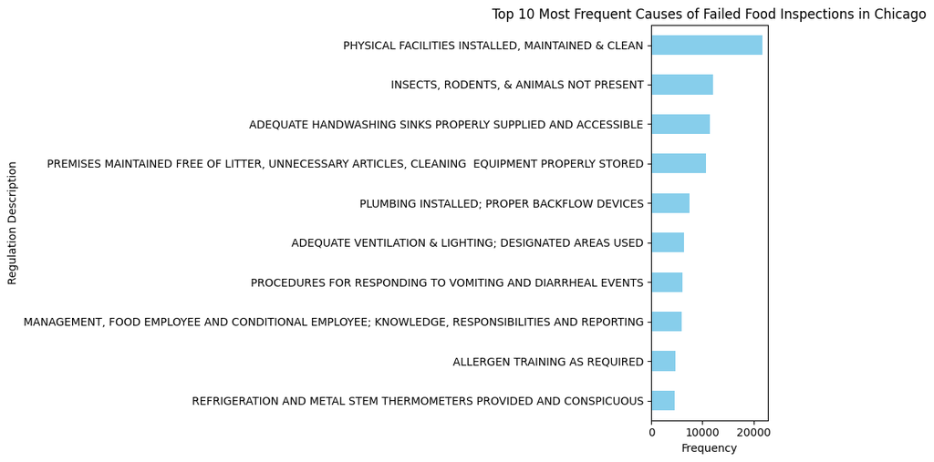

```python
# Plot the top 10 most frequent regulation descriptions
plt.figure(figsize=(10,6))
regulation_count.plot(kind='barh', color='skyblue')
plt.title('Top 10 Most Frequent Causes of Failed Food Inspections in Chicago')
plt.xlabel('Frequency')
plt.ylabel('Regulation Description')
plt.gca().invert_yaxis()  # Invert the y-axis to show the most frequent at the top
plt.tight_layout()
plt.show()
```

### 4. Tokenize the comments and provide a count of the top 10:

1. Raw tokens
2. Preprocessed tokens
3. Preprocessed tokens + Porter stemmer
4. Preprocessed tokens + Lancaster stemmer
5. Preprocessed tokens + lemmatization

```python
# Function to preprocess comments
def preprocess_text(text):
    # Convert to lowercase
    text = text.lower()
    # Tokenize the text
    tokens = word_tokenize(text)
    # Remove punctuation and stopwords
    stop_words = set(stopwords.words('english'))
    tokens = [token for token in tokens if token not in string.punctuation and token not in stop_words]
    return tokens
```

```python
# Prepare the comments data
comments = violations_df['Comments'].dropna()
```

```python
# comments
```

```python
# Tokenize the comments (raw tokens)
raw_tokens = [word_tokenize(comment) for comment in comments]
```

```python
# raw_tokens
```

```python
# Preprocess the comments (lowercase, remove punctuation and stopwords)
preprocessed_tokens = [preprocess_text(comment) for comment in comments]
```

```python
# preprocessed_tokens
## It is a list in list
```

```python
# Porter Stemmer
porter = PorterStemmer()
porter_tokens = [[porter.stem(token) for token in tokens] for tokens in preprocessed_tokens]
```

```python
# porter_tokens
```

```python
# Lancaster Stemmer
lancaster = LancasterStemmer()
lancaster_tokens = [[lancaster.stem(token) for token in tokens] for tokens in preprocessed_tokens]
```

```python
# lancaster_tokens
```

##### To improve lemmatization by using Part-of-Speech (POS) tagging, we can incorporate the nltk.pos_tag function and the get_wordnet_pos helper function. This will allow the NLTK WordNet lemmatizer to lemmatize words based on their POS tags (e.g., noun, verb, adjective), which improves accuracy.

```python
# Lemmatization
lemmatizer = WordNetLemmatizer()

# Helper function to convert Penn Treebank tags to WordNet POS tags
def get_wordnet_pos(treebank_tag, skip_value="n"):
    """Converts treebank tags to WordNet tags."""
    if treebank_tag.startswith('J'):
        return wordnet.ADJ
    elif treebank_tag.startswith('V'):
        return wordnet.VERB
    elif treebank_tag.startswith('N'):
        return wordnet.NOUN
    elif treebank_tag.startswith('R'):
        return wordnet.ADV
    else:
        return skip_value


# Function to lemmatize tokens with POS tagging
def lemmatize_with_pos(tokens):
    # Step 1: Get POS tags for each token
    pos_tags = nltk.pos_tag(tokens)
    # Step 2: Convert POS tags to WordNet POS format using the helper function
    pos_tags_wordnet = [(token, get_wordnet_pos(tag)) for token, tag in pos_tags]
    # Step 3: Lemmatize tokens with their corresponding POS tags
    lemmatized_tokens = [lemmatizer.lemmatize(token, pos=pos_tag) for token, pos_tag in pos_tags_wordnet]
    return lemmatized_tokens

# Lemmatization with POS tagging
lemmatized_tokens = [lemmatize_with_pos(tokens) for tokens in preprocessed_tokens]
```

```python
# lemmatized_tokens
```

```python
# Function to count tokens for top 10
def get_token_counts(token_list):
    # This is a list comprehension that flattens the nested token_list structure into a single list of tokens.
    all_tokens = [token for tokens in token_list for token in tokens]
    token_counts = pd.Series(all_tokens).value_counts().head(10)
    return token_counts
```

```python
# Get counts for the top 10 tokens in each case
raw_token_counts = get_token_counts(raw_tokens)
preprocessed_token_counts = get_token_counts(preprocessed_tokens)
porter_token_counts = get_token_counts(porter_tokens)
lancaster_token_counts = get_token_counts(lancaster_tokens)
lemmatized_token_counts = get_token_counts(lemmatized_tokens)
```

```python
# Display token counts
print("Top 10 Raw Token Counts")
print(raw_token_counts)
print("\nTop 10 Preprocessed Token Counts")
print(preprocessed_token_counts)
print("\nTop 10 Porter Stemmer Token Counts")
print(porter_token_counts)
print("\nTop 10 Lancaster Stemmer Token Counts")
print(lancaster_token_counts)
print("\nTop 10 Lemmatized Token Counts")
print(lemmatized_token_counts)
```

```
Top 10 Raw Token Counts
.             391791
AND           186657
TO            135237
THE           134566
,             132442
IN            112568
OF             87662
OBSERVED       85315
AT             82570
INSTRUCTED     80601
Name: count, dtype: int64

Top 10 Preprocessed Token Counts
observed      86435
instructed    82287
food          78040
must          69951
priority      52813
area          52466
maintain      49139
violation     46265
provide       45827
citation      42390
Name: count, dtype: int64

Top 10 Porter Stemmer Token Counts
food        97242
observ      86684
instruct    82417
must        69952
area        69473
maintain    56926
prioriti    52813
provid      52453
violat      49756
sink        46390
Name: count, dtype: int64

Top 10 Lancaster Stemmer Token Counts
```

[output cut: 9 more lines]

```
viol        49768
Name: count, dtype: int64

Top 10 Lemmatized Token Counts
food         97206
must         69951
area         69473
instruct     63980
observe      61869
maintain     56405
priority     52813
provide      52074
violation    49752
sink         46356
Name: count, dtype: int64
```

### 5. Briefly describe the differences in various tokens from:

1. Raw tokens
2. Preprocessed tokens
3. Preprocessed tokens + Porter stemmer
4. Preprocessed tokens + Lancaster stemmer
5. Preprocessed tokens + lemmatization

### 1. **Raw Tokens**

- **Description**: These tokens are directly extracted from the text without any cleaning or preprocessing. They include punctuation, stopwords (common words like "and", "to", "the"), and case-sensitive variations.
- **Examples**: Tokens like `.` (punctuation), "AND", "TO", and "THE" dominate the list.
- **Observation**: Raw tokens include many non-informative words (stopwords) and punctuation, which dilute the meaningful content. This is why common words like "AND" and punctuation marks dominate the token counts.

### 2. **Preprocessed Tokens**

- **Description**: Preprocessed tokens have undergone cleaning, which includes converting text to lowercase, removing punctuation, and eliminating stopwords. This step reduces noise and keeps only meaningful words.
- **Examples**: Tokens such as "observed", "instructed", "food", and "must" now appear at the top.
- **Observation**: After preprocessing, the focus is shifted to more informative content, and tokens represent meaningful words that contribute to the understanding of the violation context.

### 3. **Preprocessed Tokens + Porter Stemmer**

- **Description**: Porter stemming reduces words to their root form by removing common suffixes. Porter is relatively conservative and tries to balance reducing the word form while maintaining readability.
- **Examples**: Words like "observed" become "observ", "instructed" becomes "instruct", and "violation" becomes "violat".
- **Observation**: Stemming produces shorter, truncated versions of words. The tokens are often not real words but close to the root, which can improve some tasks but may lose clarity. For example, "priority" becomes "prioriti", and "violation" becomes "violat".

### 4. **Preprocessed Tokens + Lancaster Stemmer**

- **Description**: Lancaster stemming is a more aggressive stemming method compared to Porter, often producing shorter stems.
- **Examples**: "observed" becomes "observ", "instructed" becomes "instruct", and "priority" becomes "pri".
- **Observation**: Lancaster stemmer produces even more truncated tokens than Porter. This aggressive reduction may make tokens less recognizable or readable but creates a consistent root for different word forms. For example, "priority" is reduced to "pri", which might be too aggressive in certain contexts.

### 5. **Preprocessed Tokens + Lemmatization**

- **Description**: Lemmatization reduces words to their base (dictionary) form by considering the word's part of speech (POS). Unlike stemming, lemmatization retains meaningful word forms.
- **Examples**: Words like "observed" become "observe", "instructed" becomes "instruct", and "violation" stays as "violation".
- **Observation**: Lemmatization is more accurate and human-readable than stemming, as it converts words to their base form without excessive truncation. It provides a balance between reducing variations of a word and maintaining readability. For instance, "violation" remains "violation" rather than being reduced to a stem like "violat".

### Key Differences:

- **Raw Tokens**: Contain stopwords and punctuation, with minimal value for analysis.
- **Preprocessed Tokens**: Cleaned and more focused on meaningful content, but words remain unaltered.
- **Porter Stemmer**: Produces root forms of words, truncating words moderately.
- **Lancaster Stemmer**: More aggressive in truncating words, which may sometimes result in overly shortened tokens.
- **Lemmatization**: Produces base forms of words based on their POS, maintaining more readable and accurate tokens compared to stemming.

### Overall, I would choose Preprocessed Tokens + Lemmatization